[figure not shown]

# Agile Development to Support State Assessment Analyses

## Intern Update #2

**Brian Harrold and Erik Whitfield**  
July 10, 2025

# Recap: Project Objectives

- Develop modular, reusable R functions to support education data analysis
- Focus on transparency, reproducibility, and efficiency
- Build tools for cohort tracking, participation metrics, and student mobility
- Provide interactive, well-documented outputs for users
- **Shift the role of the state analyst from creator to reviewer**

# `cohortED` package

[figure not shown]

- [Quarto Website](https://stat-brain.github.io/cohortED/)
- [GitHub Repository](https://github.com/stat-brain/cohortED)

## Significance of `cohortED`

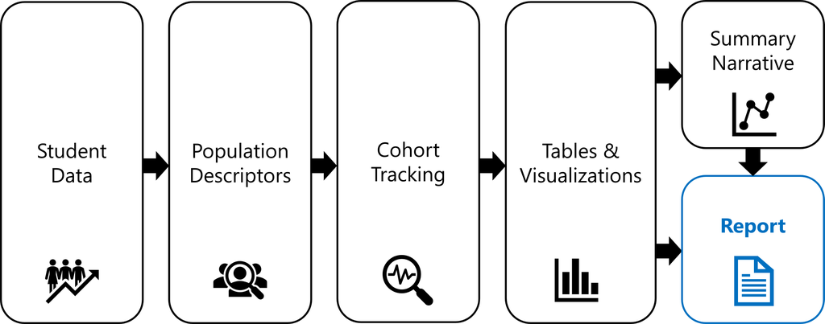

## Recent Improvements

- Enhancing Processes
- Bolster Reporting
- Clarifying Support
- Defining Workflow

## Enhancing Processes

- Longitudinal-population descriptors
  - Describing the population in terms of cohorts
- Persistence-based analysis
  - Visualizing the changes in the population

## Visualizing Changes

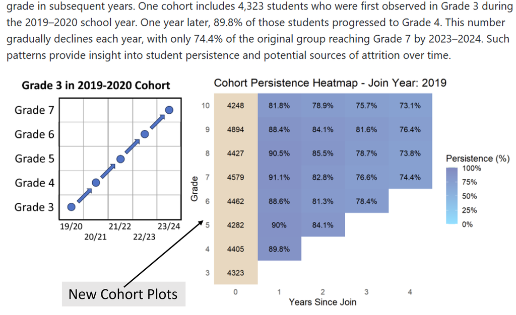

## Bolster Reporting

- Auto-generated text
  - Compares outputs from analysis functions
  - Conditionally constructs and combines responses
- User-oriented logic
  - Suggests plots or tables as needed
  - Driven by conditional rules
- Report-ready narrative

## Within the Report

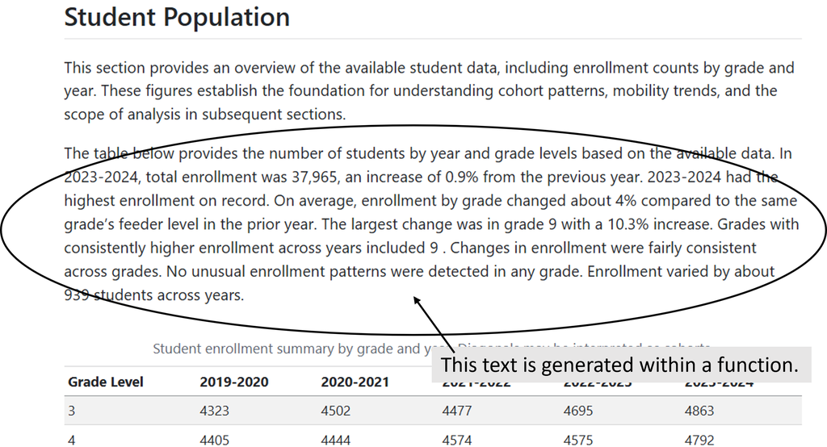

## Clarifying Support

- Cleanly-structured documentation
  - Searchable website with explanations
  - Summaries with collapsible details

## Live Example

[figure not shown]

[Open Live Example ↗](https://stat-brain.github.io/cohortED/analysis_functions.html)

## Defining Workflow

- Well-defined structure
  - Additive functionality
  - Streamlined procedures
- Input-structuring tools
  - Facilitate formatting data

## Workflow Concept

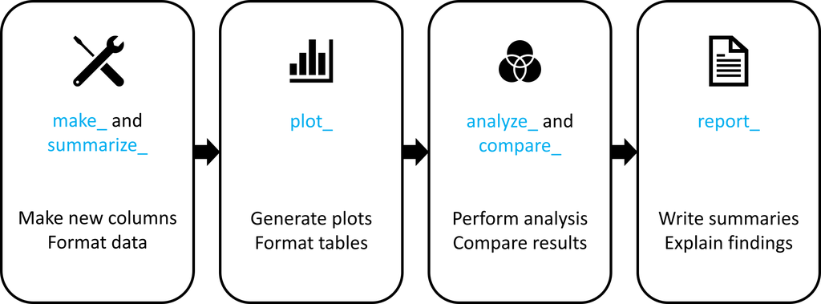

## Example Report

[video not shown]

[View Example Reports](https://stat-brain.github.io/cohortED/example_reports.html)

## Next Steps

- Implement school/district filters
  - Develop support for school/district level transitions
- Document package workflows
  - Supporting users implement functionality
- Expand reporting capabilities
  - Potential for new reports or additional sections

## In the Next Two Weeks

- Continue developing functionality and reporting
  - Further Reporting and Narration
  - Expound Performance Comparisons
- Prepare NCME Proposals:
  - Mini (2-hour) Training Session
  - Innovative Demonstration
- Apply Package to Mississippi Assessment Data

## Potential Extensions (Later)

- Alternative Assessments
- Support Services
- Dropout vs. Graduation
- Chronic Absenteeism
- Any other **transition**!

## Desired Feedback

- Frequently asked questions about student mobility
- Related reports or articles to guide future work
- Advice concerning NCME Proposals